# Analyses for paper with Laura and Doris

Heath Blackmon

February 1, 2016

We need to add a few analyses to this paper and since we first started a nice tree has become available: [Phylogenomics resolves the timing and pattern of insect evolution](http://science.sciencemag.org.ezp1.lib.umn.edu/content/346/6210/763.full.pdf+html?) this paper includes a consensus tree with node dates equal to the median of from their bayesian analysis. This tree has 1-4 tips for each order.

```r
library(geiger)
library(phytools)
```

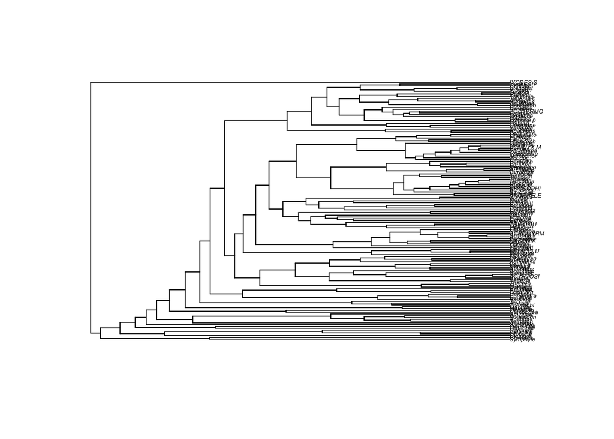

```r
tree <- read.nexus("insects.nex")
plot(tree, cex = .4)
```

`write.csv(tree$tip.label,file="names.csv")`

Outside of R I created a table that has the tree tip names in the first collumn. The second column has each order name entered only one time (so mostly blanks). So the next step is to prune this tree so we have a single tip for each order.

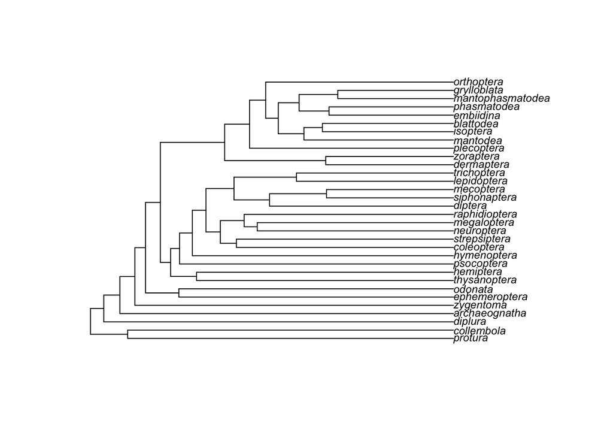

```r
taxa <- read.csv("names.csv", as.is = T)

# create a vector with length the same as number of orders
nums <- rep(1, sum(taxa[, 2] != ""))

# provide the correct order names for the tips we will keep
names(nums) <- taxa[, 1][taxa[, 2] != ""]

# prune the tree to just those tips we are keeping
new.tree <- treedata(tree, nums, warnings=F)[[1]]

# trade out original tip names with order names
for(i in 1:length(new.tree$tip.label)){
  hit <- which(taxa[, 1] == new.tree$tip.label[i])
  new.tree$tip.label[i] <- taxa[hit, 2]
}

# now plot new tree
plot(new.tree, cex = .75)
```

```r
# that looks good, lets clean up some
rm(taxa, hit, i, nums, tree)
```

Many of our methods are sensitive and perform poorly with trees that have long branches for this reason lets go ahead scale are tree to unit length. This wont effect relative rates nor transition inference but if we want to report actual rates we will need to untransform.

```r
new.tree <-rescale(new.tree, model="depth", 1)
```

Ok now that we have a dated consensus phylogeny we can do several analyses that I felt unsure of previously. For the first one lets do the reconstruction of the sex chromosome system. The first problem that we face in this case is that we have variation in some groups however, for most groups there is a clear consensus. The approach that we will use is to simply take the probability of being in each tip state as being equal to the frequency of that state in an order. For instance if 90% of records are XY and 10% of records are XO we would place a prior probability of 90% on the state XY and a 10% prior probability on the state XO.

The first thing that we will do is make the empty state matrix

```r
scs.states <- c("XY", "XO", "ZW", "ZO", "HD")
states <- matrix(,length(new.tree$tip.label), length(scs.states))
colnames(states) <- scs.states
row.names(states) <- new.tree$tip.label
rm(scs.states)
```

Now we will fill this in

```r
setwd("~/Desktop/Dropbox/projects/SexChromosomes (1)/invertebrates/InsectReview/new.version/data")
data <- read.csv("tos.data.old.csv", as.is = T)
for(i in 1:nrow(states)){
  temp.data <- data[tolower(data$Order) == row.names(states)[i], 6]
  states[i, 1] <- sum(temp.data == "XY" | temp.data == "complex XY|homomorphic" |
                      temp.data == "complex XY" | temp.data == "XY|homomorphic")
  states[i, 2] <- sum(temp.data == "XO" | temp.data == "complex XO")
  states[i, 3] <- sum(temp.data == "ZW" | temp.data == "complex ZW")
  states[i, 4] <- sum(temp.data == "ZO")
  temp.data <- data[tolower(data$Order) == row.names(states)[i], 9]
  states[i, 5] <- sum(temp.data == "paternal genome elimination" | temp.data == "arrhenotoky")
}
# fix notoptera and hemiptera
# hemiptera is based on Laura's data from 12 Feb.
states[17,1] <- 2
states[4, c(1,2)] <- c(281, 154)
knitr::kable(states)
```

|  | XY | XO | ZW | ZO | HD |
| --- | --- | --- | --- | --- | --- |
| hymenoptera | 0 | 0 | 0 | 0 | 1591 |
| diptera | 1198 | 42 | 7 | 0 | 0 |
| protura | 3 | 0 | 0 | 0 | 0 |
| hemiptera | 281 | 154 | 0 | 0 | 247 |
| embiidina | 0 | 8 | 0 | 0 | 0 |
| siphonaptera | 6 | 0 | 0 | 0 | 0 |
| zygentoma | 0 | 3 | 0 | 0 | 0 |
| lepidoptera | 0 | 0 | 30 | 10 | 0 |
| ephemeroptera | 6 | 2 | 0 | 0 | 0 |
| blattodea | 0 | 108 | 0 | 0 | 0 |
| mecoptera | 1 | 13 | 0 | 0 | 0 |
| odonata | 17 | 400 | 0 | 0 | 0 |
| diplura | 0 | 0 | 0 | 0 | 0 |
| coleoptera | 3348 | 766 | 0 | 0 | 1 |
| psocoptera | 2 | 91 | 0 | 0 | 0 |
| dermaptera | 49 | 2 | 0 | 0 | 0 |
| grylloblata | 2 | 0 | 0 | 0 | 0 |
| trichoptera | 0 | 0 | 0 | 15 | 0 |
| raphidioptera | 6 | 0 | 0 | 0 | 0 |
| archaeognatha | 0 | 0 | 0 | 0 | 0 |
| mantodea | 41 | 60 | 0 | 0 | 0 |
| isoptera | 63 | 1 | 0 | 0 | 0 |
| neuroptera | 72 | 2 | 0 | 0 | 0 |
| plecoptera | 1 | 11 | 0 | 0 | 0 |
| megaloptera | 4 | 0 | 0 | 0 | 0 |
| collembola | 0 | 17 | 0 | 0 | 10 |
| strepsiptera | 1 | 0 | 0 | 0 | 0 |
| mantophasmatodea | 0 | 0 | 0 | 0 | 0 |
| orthoptera | 58 | 223 | 0 | 0 | 0 |
| thysanoptera | 0 | 0 | 0 | 0 | 24 |
| phasmatodea | 13 | 68 | 0 | 0 | 0 |
| zoraptera | 1 | 0 | 0 | 0 | 0 |

```r
rowSums(states)
```

```
##      hymenoptera          diptera          protura        hemiptera
##             1591             1247                3              682
##        embiidina     siphonaptera        zygentoma      lepidoptera
##                8                6                3               40
##    ephemeroptera        blattodea        mecoptera          odonata
##                8              108               14              417
##          diplura       coleoptera       psocoptera       dermaptera
##                0             4115               93               51
##      grylloblata      trichoptera    raphidioptera    archaeognatha
##                2               15                6                0
##         mantodea         isoptera       neuroptera       plecoptera
##              101               64               74               12
##      megaloptera       collembola     strepsiptera mantophasmatodea
##                4               27                1                0
##       orthoptera     thysanoptera      phasmatodea        zoraptera
##              281               24               81                1
```

First step in the ancestral state reconstruction is changing these counts into proportions. Three orders have no data so they will have equal probability of being in any state.

```r
for(i in 1:nrow(states)){
  if(sum(states[i, ]) == 0) states[i, ] <- c(1,1,1,1,1)
  states[i, ] <- states[i, ] / sum(states[i, ])
}
knitr::kable(states)
```

|  | XY | XO | ZW | ZO | HD |
| --- | --- | --- | --- | --- | --- |
| hymenoptera | 0.0000000 | 0.0000000 | 0.0000000 | 0.00 | 1.0000000 |
| diptera | 0.9607057 | 0.0336808 | 0.0056135 | 0.00 | 0.0000000 |
| protura | 1.0000000 | 0.0000000 | 0.0000000 | 0.00 | 0.0000000 |
| hemiptera | 0.4120235 | 0.2258065 | 0.0000000 | 0.00 | 0.3621701 |
| embiidina | 0.0000000 | 1.0000000 | 0.0000000 | 0.00 | 0.0000000 |
| siphonaptera | 1.0000000 | 0.0000000 | 0.0000000 | 0.00 | 0.0000000 |
| zygentoma | 0.0000000 | 1.0000000 | 0.0000000 | 0.00 | 0.0000000 |
| lepidoptera | 0.0000000 | 0.0000000 | 0.7500000 | 0.25 | 0.0000000 |
| ephemeroptera | 0.7500000 | 0.2500000 | 0.0000000 | 0.00 | 0.0000000 |
| blattodea | 0.0000000 | 1.0000000 | 0.0000000 | 0.00 | 0.0000000 |
| mecoptera | 0.0714286 | 0.9285714 | 0.0000000 | 0.00 | 0.0000000 |
| odonata | 0.0407674 | 0.9592326 | 0.0000000 | 0.00 | 0.0000000 |
| diplura | 0.2000000 | 0.2000000 | 0.2000000 | 0.20 | 0.2000000 |
| coleoptera | 0.8136087 | 0.1861482 | 0.0000000 | 0.00 | 0.0002430 |
| psocoptera | 0.0215054 | 0.9784946 | 0.0000000 | 0.00 | 0.0000000 |
| dermaptera | 0.9607843 | 0.0392157 | 0.0000000 | 0.00 | 0.0000000 |
| grylloblata | 1.0000000 | 0.0000000 | 0.0000000 | 0.00 | 0.0000000 |
| trichoptera | 0.0000000 | 0.0000000 | 0.0000000 | 1.00 | 0.0000000 |
| raphidioptera | 1.0000000 | 0.0000000 | 0.0000000 | 0.00 | 0.0000000 |
| archaeognatha | 0.2000000 | 0.2000000 | 0.2000000 | 0.20 | 0.2000000 |
| mantodea | 0.4059406 | 0.5940594 | 0.0000000 | 0.00 | 0.0000000 |
| isoptera | 0.9843750 | 0.0156250 | 0.0000000 | 0.00 | 0.0000000 |
| neuroptera | 0.9729730 | 0.0270270 | 0.0000000 | 0.00 | 0.0000000 |
| plecoptera | 0.0833333 | 0.9166667 | 0.0000000 | 0.00 | 0.0000000 |
| megaloptera | 1.0000000 | 0.0000000 | 0.0000000 | 0.00 | 0.0000000 |
| collembola | 0.0000000 | 0.6296296 | 0.0000000 | 0.00 | 0.3703704 |
| strepsiptera | 1.0000000 | 0.0000000 | 0.0000000 | 0.00 | 0.0000000 |
| mantophasmatodea | 0.2000000 | 0.2000000 | 0.2000000 | 0.20 | 0.2000000 |
| orthoptera | 0.2064057 | 0.7935943 | 0.0000000 | 0.00 | 0.0000000 |
| thysanoptera | 0.0000000 | 0.0000000 | 0.0000000 | 0.00 | 1.0000000 |
| phasmatodea | 0.1604938 | 0.8395062 | 0.0000000 | 0.00 | 0.0000000 |
| zoraptera | 1.0000000 | 0.0000000 | 0.0000000 | 0.00 | 0.0000000 |

```r
rm(i, temp.data, data)
#colnames(states) <- 1:5
```

Now lets try doing the ancestral state reconstruction using an ML approach. I am going to use Liam’s stochastic mapping approach becuase it will allow me to have uncertainty in the tip states. This will allow me to use the information that we have for thousands of tips while still using our order backbone tree.

```r
# also we dont have data for archaegnatha and diplura so lets drop those from the analysis
new.tree <- drop.tip(new.tree, tip = c("diplura", "archaeognatha"))
states <- states[!row.names(states) %in% c("diplura", "archaeognatha"),]

reconstruction <- make.simmap(tree = new.tree, x = states, Q="mcmc",
                              model="ARD", pi="estimated", nsim=100)
```

```
## Running MCMC burn-in. Please wait....
## Running 10000 generations of MCMC, sampling every 100 generations.
## Please wait....
```

```
## make.simmap is simulating with a sample of Q from
## the posterior distribution
##
## Mean Q from the posterior is
## Q =
##            XY         XO         ZW         ZO         HD
## XY -1.8201322  0.7480872  0.3264602  0.3392944  0.4062903
## XO  0.8698304 -2.3152107  0.4400236  0.4013571  0.6039996
## ZW  1.5808464  1.6511544 -5.3683283  1.1010366  1.0352909
## ZO  1.3192184  1.4791769  1.1465395 -4.9219354  0.9770006
## HD  1.4135718  1.0435511  0.7575991  0.8849774 -4.0996993
## and (mean) root node prior probabilities
## pi =
##         XY         XO         ZW         ZO         HD
## 0.38279878 0.30097275 0.08966862 0.09310087 0.13345898
```

```
## Done.
```

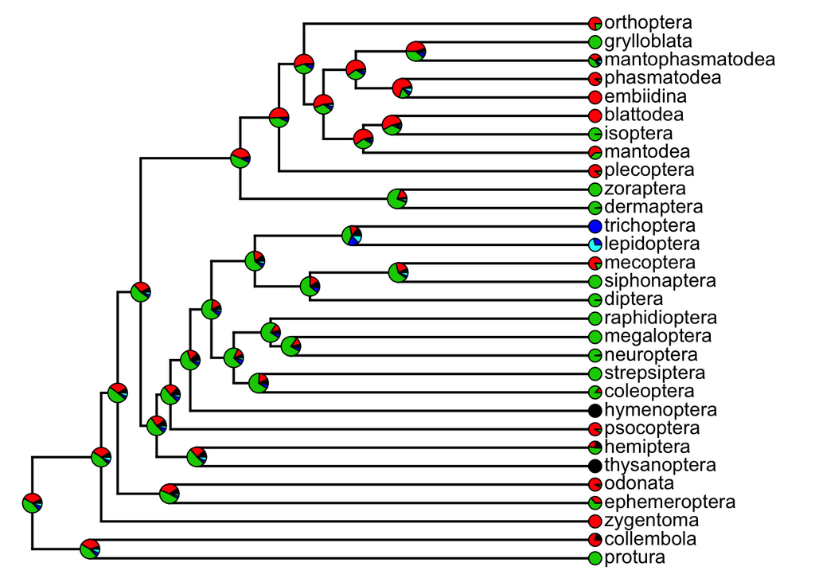

```
## 100 trees with a mapped discrete character with states:
##  HD, XO, XY, ZO, ZW
##
## trees have 45.78 changes between states on average
##
## changes are of the following types:
##      HD,XO HD,XY HD,ZO HD,ZW XO,HD XO,XY XO,ZO XO,ZW XY,HD XY,XO XY,ZO
## x->y  2.09  2.67   1.4  1.15  2.61  5.56  1.73  1.76  3.23  5.91   2.2
##      XY,ZW ZO,HD ZO,XO ZO,XY ZO,ZW ZW,HD ZW,XO ZW,XY ZW,ZO
## x->y  2.08  1.05  2.22  2.47  1.06  1.06  2.57  2.04  0.92
##
## mean total time spent in each state is:
##             XY        XO         ZW         ZO         HD    total
## raw  8.8063159 5.9657489 0.91243630 1.19098450 1.60887374 18.48436
## prop 0.4764199 0.3227458 0.04936261 0.06443201 0.08703974  1.00000
```

```r
#plotSimmap(reconstruction)
describe.simmap(reconstruction, plot=T)
```

This actually isn’t bad as an unconstrained first approximation. However, we would like to build several assumptions into our model that will reduce the number of parameters and make use of what we know from other sources of data.

Here is the matrix form of those assumptions:

```r
my.mod <- matrix(c(0,4,0,0,0,
                   1,0,0,0,0,
                   2,2,0,5,0,
                   0,0,6,0,0,
                   3,3,3,3,0), 5)
```

Now lets try rerunning the reconstruction in this first one we will say that we know the root is either XY or XO.

```r
reconstruction <- make.simmap(tree = new.tree, x = states, Q="mcmc",
                              model=my.mod, pi=c(1,1,0,0,0), nsim=100)
```

```
## Running MCMC burn-in. Please wait....
## Running 10000 generations of MCMC, sampling every 100 generations.
## Please wait....
##
## make.simmap is simulating with a sample of Q from
## the posterior distribution
##
## Mean Q from the posterior is
## Q =
##           XY        XO         ZW        ZO        HD
## XY -1.196151  0.876144  0.1359499  0.000000 0.1840567
## XO  1.242998 -1.563005  0.1359499  0.000000 0.1840567
## ZW  0.000000  0.000000 -1.5756216  1.391565 0.1840567
## ZO  0.000000  0.000000  0.9325948 -1.116652 0.1840567
## HD  0.000000  0.000000  0.0000000  0.000000 0.0000000
## and (mean) root node prior probabilities
## pi =
## [1] 0.5 0.5 0.0 0.0 0.0
```

```
## Done.
```

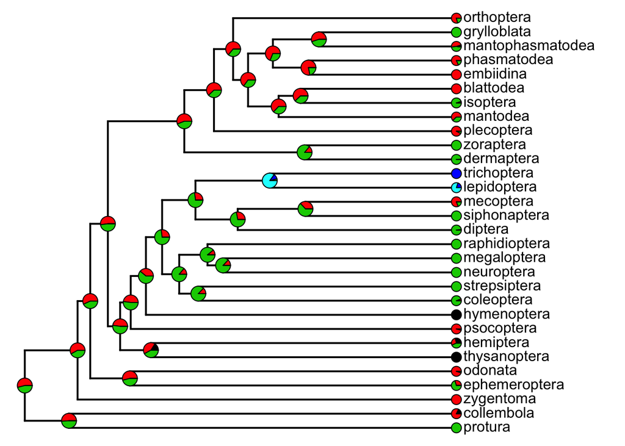

```
## 100 trees with a mapped discrete character with states:
##  HD, XO, XY, ZO, ZW
##
## trees have 23.09 changes between states on average
##
## changes are of the following types:
##      HD,XO HD,XY HD,ZO HD,ZW XO,HD XO,XY XO,ZO XO,ZW XY,HD XY,XO XY,ZO
## x->y     0     0     0     0     1  9.52     0  0.33  1.26  8.58     0
##      XY,ZW ZO,HD ZO,XO ZO,XY ZO,ZW ZW,HD ZW,XO ZW,XY ZW,ZO
## x->y  0.83  0.05     0     0  0.16  0.05     0     0  1.31
##
## mean total time spent in each state is:
##             XY        XO         ZW         ZO        HD    total
## raw  9.2744557 7.1773256 0.62959968 0.34226263 1.0607157 18.48436
## prop 0.5017461 0.3882918 0.03406121 0.01851634 0.0573845  1.00000
```

```r
#plotSimmap(reconstruction)
describe.simmap(reconstruction, plot=T)
```

Now we can compare how our root treatment effects our conclusions impact our reconstructed states. This time we will allow the roots to be estimated from the steady state distribution.

```r
reconstruction2 <- make.simmap(tree = new.tree, x = states, Q="mcmc",
                              model=my.mod, pi="estimated", nsim=1000)
```

```
## Running MCMC burn-in. Please wait....
## Running 1e+05 generations of MCMC, sampling every 100 generations.
## Please wait....
##
## make.simmap is simulating with a sample of Q from
## the posterior distribution
##
## Mean Q from the posterior is
## Q =
##           XY         XO         ZW        ZO        HD
## XY -1.168952  0.8553132  0.1293994  0.000000 0.1842398
## XO  1.255766 -1.5694052  0.1293994  0.000000 0.1842398
## ZW  0.000000  0.0000000 -1.8476457  1.663406 0.1842398
## ZO  0.000000  0.0000000  0.9370636 -1.121303 0.1842398
## HD  0.000000  0.0000000  0.0000000  0.000000 0.0000000
## and (mean) root node prior probabilities
## pi =
##            XY            XO            ZW            ZO            HD
## -4.066153e-05  1.731305e-04  1.565460e-04  5.848039e-05  9.996525e-01
```

[output not shown]

[output cut: 397 more lines]

[output not shown]

```
## Done.
```

now lets put these two constructions side by side and see what they look like

```r
par(mfcol=c(1,2))
describe.simmap(reconstruction, plot=T)
```

```
## 100 trees with a mapped discrete character with states:
##  HD, XO, XY, ZO, ZW
##
## trees have 23.09 changes between states on average
##
## changes are of the following types:
##      HD,XO HD,XY HD,ZO HD,ZW XO,HD XO,XY XO,ZO XO,ZW XY,HD XY,XO XY,ZO
## x->y     0     0     0     0     1  9.52     0  0.33  1.26  8.58     0
##      XY,ZW ZO,HD ZO,XO ZO,XY ZO,ZW ZW,HD ZW,XO ZW,XY ZW,ZO
## x->y  0.83  0.05     0     0  0.16  0.05     0     0  1.31
##
## mean total time spent in each state is:
##             XY        XO         ZW         ZO        HD    total
## raw  9.2744557 7.1773256 0.62959968 0.34226263 1.0607157 18.48436
## prop 0.5017461 0.3882918 0.03406121 0.01851634 0.0573845  1.00000
```

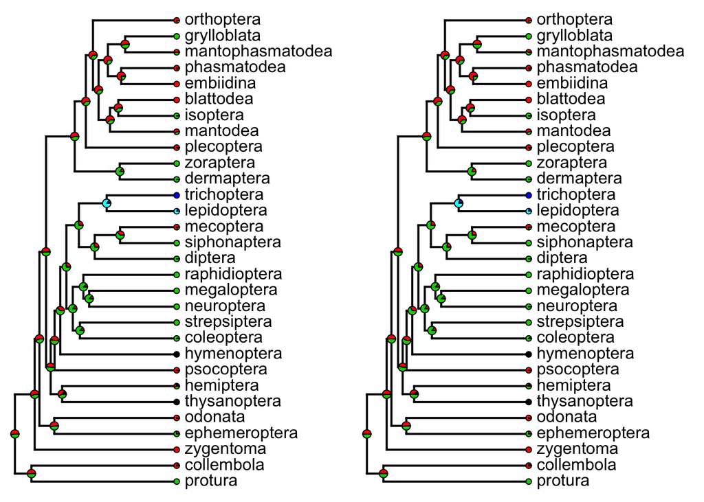

```
## 1000 trees with a mapped discrete character with states:
##  HD, XO, XY, ZO, ZW
##
## trees have 22.629 changes between states on average
##
## changes are of the following types:
##      HD,XO HD,XY HD,ZO HD,ZW XO,HD XO,XY XO,ZO XO,ZW XY,HD XY,XO XY,ZO
## x->y     0     0     0     0 0.949 9.036     0  0.34 1.352 8.426     0
##      XY,ZW ZO,HD ZO,XO ZO,XY ZO,ZW ZW,HD ZW,XO ZW,XY ZW,ZO
## x->y 0.879 0.031     0     0 0.204 0.073     0     0 1.339
##
## mean total time spent in each state is:
##             XY        XO         ZW         ZO         HD    total
## raw  9.4915260 7.0222973 0.59630573 0.35171719 1.02251305 18.48436
## prop 0.5134896 0.3799048 0.03226002 0.01902783 0.05531774  1.00000
```

```r
describe.simmap(reconstruction2, plot=T)
```

So we see that the extra constraint doesnt greatly change our ancestral states. With that in mind lets focus on the second reconstruction which does not constrain the root and allows it to be estimated from the Q matrix.

Now let build a nice plot for the manuscript so we can talk about it.

```r
#first exctract out the values we want
for(i in 1:length(new.tree$tip.label)){
  name<- new.tree$tip.label[i]
  new.tree$tip.label[i] <- paste0(toupper(substr(name, 1, 1)),
                                  substr(name, 2, nchar(name)))
}
hist <- summary(reconstruction2, plot=F)
plot(new.tree,cex=0.5, label.offset=.02)
#             HD           XO          XY       ZO         ZW
cols <- c("#ef6548", "#a1d99b", "#005a32", "#084594", "#9ecae1")
nodelabels(pie=hist$ace,piecol=cols,cex=0.5, width=2, height=1)
#             HD           XO          XY       ZO         ZW
cols <- c("#ef6548", "#005a32", "#a1d99b", "#084594"  ,"#9ecae1")
tiplabels(pie=states[,c(5, 1:4)],piecol=cols,cex=0.5)

#legend
text(x=rep(0.05, 5), y=c(30,29,28,27,26),
     label=c("XY", "XO", "ZW", "ZO", "HD/PGE"),
     cex=.7, pos=4)
points(x=rep(0.05, 5), y=c(30,29,28,27,26), cex=1.4,
       pch=16, col=cols[c(2:5, 1)])

hist$ace
```

```
##       HD    XO    XY    ZO    ZW
## 31 0.000 0.516 0.484 0.000 0.000
## 32 0.000 0.500 0.500 0.000 0.000
## 33 0.000 0.520 0.480 0.000 0.000
## 34 0.000 0.508 0.492 0.000 0.000
## 35 0.000 0.520 0.480 0.000 0.000
## 36 0.000 0.483 0.517 0.000 0.000
## 37 0.000 0.445 0.555 0.000 0.000
## 38 0.113 0.390 0.495 0.000 0.002
## 39 0.000 0.418 0.582 0.000 0.000
## 40 0.000 0.329 0.671 0.000 0.000
## 41 0.000 0.231 0.769 0.000 0.000
## 42 0.000 0.160 0.840 0.000 0.000
## 43 0.000 0.150 0.850 0.000 0.000
## 44 0.000 0.130 0.870 0.000 0.000
## 45 0.000 0.116 0.884 0.000 0.000
## 46 0.000 0.227 0.773 0.000 0.000
## 47 0.000 0.206 0.794 0.000 0.000
## 48 0.000 0.252 0.748 0.000 0.000
## 49 0.000 0.018 0.060 0.132 0.790
## 50 0.000 0.528 0.472 0.000 0.000
## 51 0.000 0.180 0.820 0.000 0.000
## 52 0.000 0.623 0.377 0.000 0.000
## 53 0.000 0.649 0.351 0.000 0.000
## 54 0.000 0.657 0.343 0.000 0.000
## 55 0.000 0.663 0.337 0.000 0.000
## 56 0.000 0.657 0.343 0.000 0.000
## 57 0.000 0.674 0.326 0.000 0.000
## 58 0.000 0.772 0.228 0.000 0.000
## 59 0.000 0.511 0.489 0.000 0.000
```

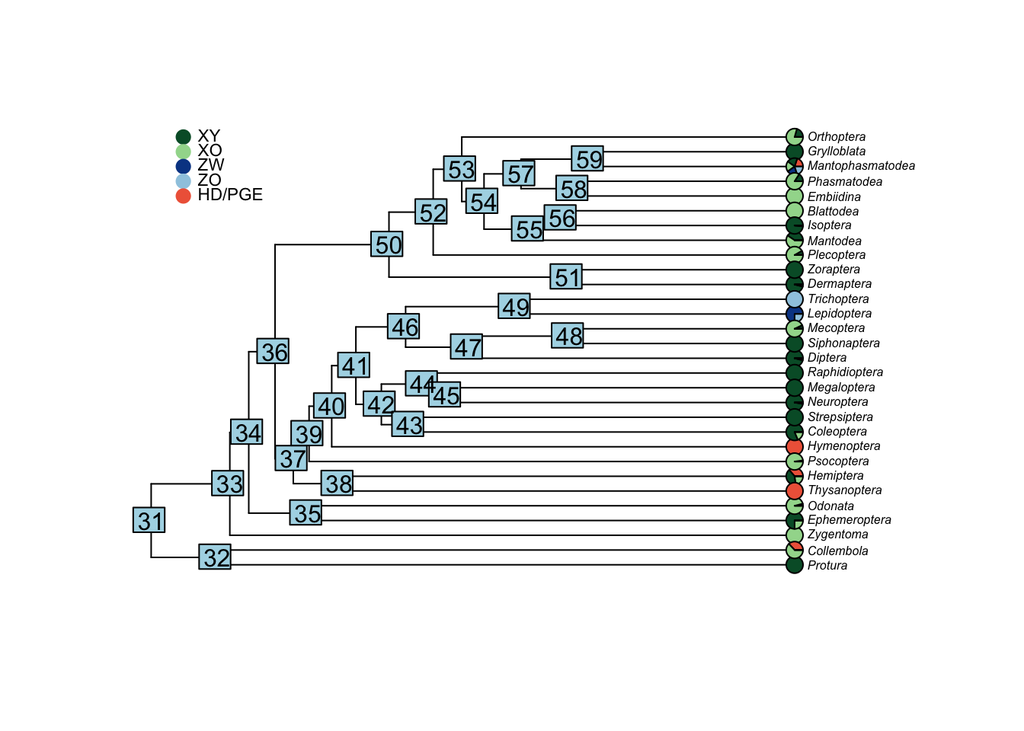

```r
nodelabels()
```